# Analytics

Assignment 1

Tinotenda Mutsemi (MTSTIN007)

2024-03-05

# Question 1

## Question 1a

After splitting the data into training and test sets using an 80/20 split, we fit a homogeneous tree by setting the minimum size of the terminal nodes to 2 and the minimum deviance to 0. This will achieve homogenous terminal nodes since the tree will always split for any deviance reduction and any node has at least 2 observations. We then plot the tree to see the structure.

This tree is grossly overfitted, and we see that location features and count result in the most classifications error reduction.

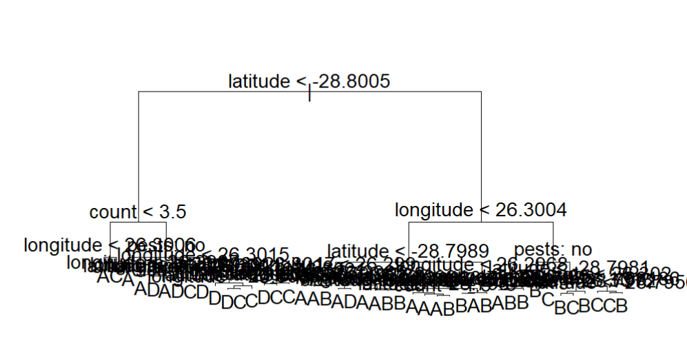

Overfitted Homogenous Mealies Tree

We then test the perfomance with the 20% we splitted from the data. Below is the confusion matrix of the test showing a misclassification rate of 8%.

|  | A Predicted | B Predicted | C Predicted | D Predicted |
| --- | --- | --- | --- | --- |
| A Actual | 40 | 3 | 0 | 1 |
| B Actual | 2 | 70 | 1 | 0 |
| C Actual | 0 | 1 | 31 | 5 |
| D Actual | 4 | 0 | 3 | 89 |

## Question 1b

We use 10 fold cross validation and the misclassification error as the cost function. Figure 2 shows cross validation error against the number of terminal nodes and the penality alpha.

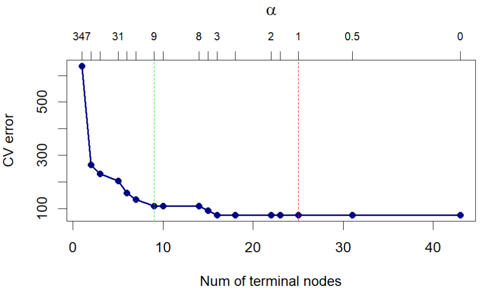

CV error for each tree size

Comparing the test misclassification rate with the one from a), this tree performs worse than from an overfitted tree. We however gain interpretability at the cost of a sightly higher missclassification rate and perhaps best out of sample predictions.

|  | A Predicted | B Predicted | C Predicted | D Predicted |
| --- | --- | --- | --- | --- |
| A Actual | 30 | 10 | 1 | 4 |
| B Actual | 1 | 71 | 1 | 0 |
| C Actual | 0 | 3 | 22 | 12 |
| D Actual | 0 | 2 | 0 | 94 |

## Question 1c

We plot the location of the mealies on a scatter plot with the quality of the mealies represented by the color of the points. Tree methods partion the feature space othogonally and therefore we rotate the feature space to see if we can get a better partitioning of the feature space.

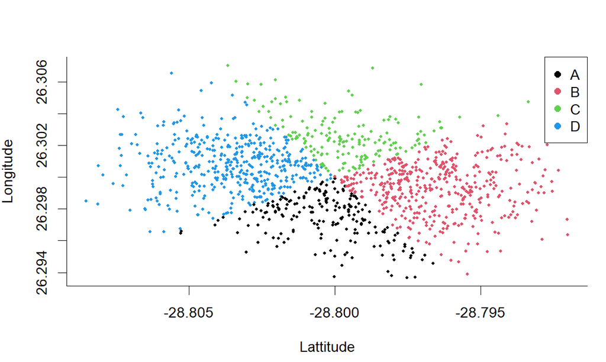

Mealies feature space

Now we apply 10 fold cross validation to the rotated data. We then plot the misclassification error against the rotation angle. We see that the misclassification error is lowest at 0.974 radians.

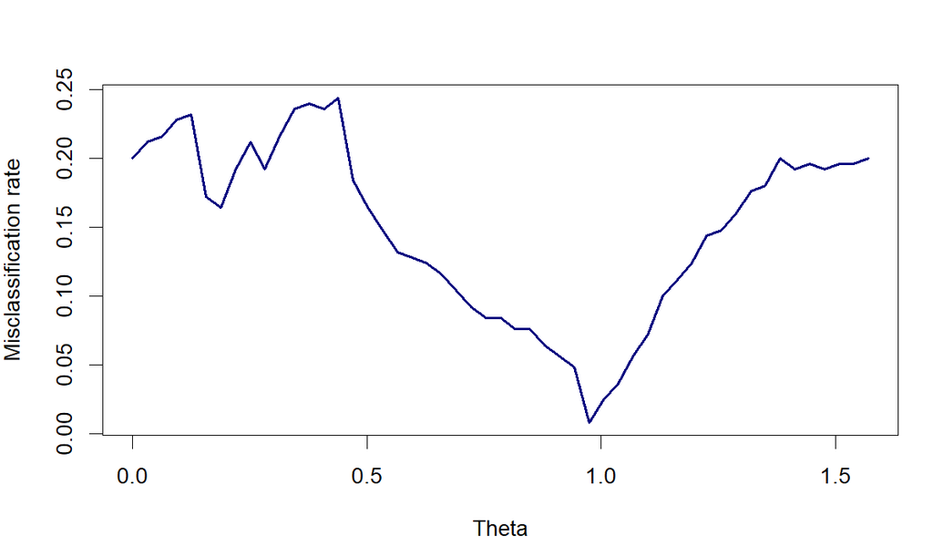

Misclassification rates for theta

The misclassification rate is 0.4%. This is expected because the tree method partions the feature space orthogonally and therefore rotating the feature space will find lower misclassification rates.

Below is the confusion matrix for the rotated feature space. This tree perform very well even on unseen data.

|  | A Predicted | B Predicted | C Predicted | D Predicted |
| --- | --- | --- | --- | --- |
| A Actual | 44 | 0 | 0 | 0 |
| B Actual | 0 | 73 | 0 | 1 |
| C Actual | 0 | 0 | 37 | 0 |
| D Actual | 0 | 0 | 0 | 95 |

# Question 2

We do some exploratory analysis to see the variables correlation. Below is the scatter plot of First Inn Score and Bowl2 Strength, this gives us a feel of the data we are modelling.

We remove the match id from the regression, standardize the data and use dummy variables for the categorical variables.

We also remove defending team and chasing team from the regression. As they are not consistent across seasons thus not useful for predictions.

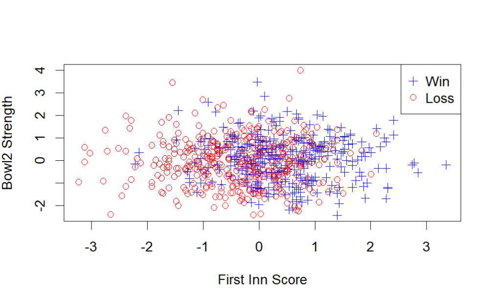

First Inn Score vs the team Bowling in the second round

## Question 2a

After some feature selection we fit a vanilla model to get a feel of the model performance. We see that only First Inn score is significant.

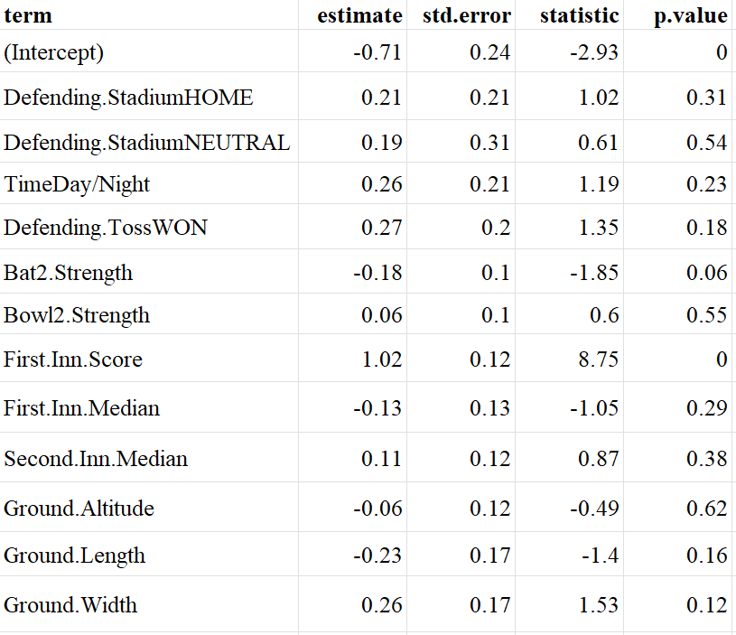

Coefficients of vanilla logistic regression

We then fit an elastic net model to the data. We use cross validation to select the best alpha and lambda. We sequence alpha from 0 to 1 and use 10 fold cross validation to select the best lambda for each alpha.

The plot below shows the misclassificatioin rates for each alpha. The alpha yielding the least misclassification error is 0.3

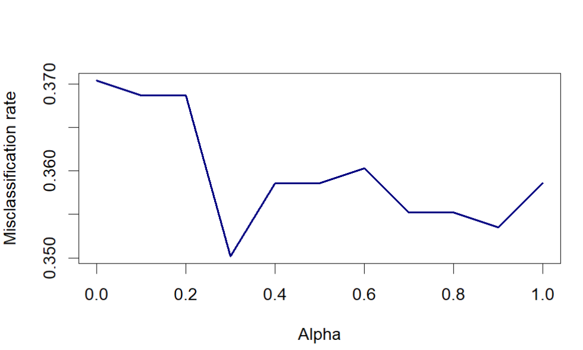

Misclassification Rates for each Alpha at the best Lambda

We fit the elastic net model with alpha = 0.3 and plot the coefficients. The best lambda is 0.28, as shown in figure 6.

We see that at these hyperparameter we only have 1 feature in the model.

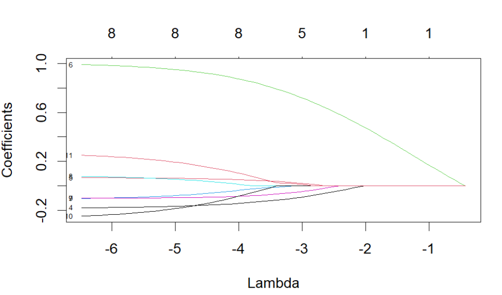

Coefficients at lambda 0.28 is First Inn Score only

First Inn Score with a coefficient of 0.25. This means that a unit increase in the first innings score increases the log odds of winning by 0.25.

Below is the confusion matrix from testing the model.

Confusion Matrix

|  | Loss Predicted | Win Predicted |
| --- | --- | --- |
| Loss Actual | 80 | 10 |
| Win Actual | 40 | 19 |

The F score is 0.43 showing that the model is not good because the score is less than 0.5.

# Question 2b

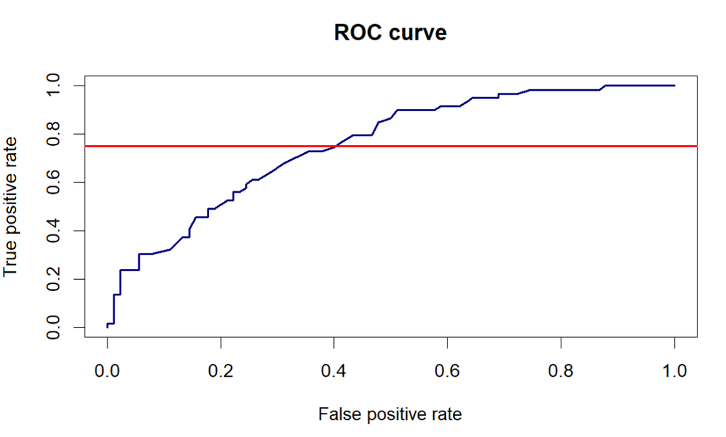

ROC curve with 0.75 recall line

# Question 3

## Question 3a

We do some exploratory analysis to see the variables correlation. We see that Shimmer variables are highly correlated with each other and so are Jitter variables.

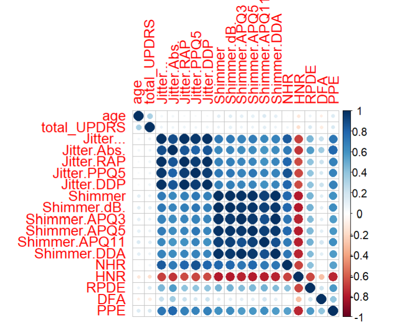

Variable correlations for Parkinsons data set

### Question 3a i

We fit an elastic net with alpha = 1 for lasso regularization. Our final model ( lambda.1se) has test MSE of 95, and variables age, sex, DFA with high significance.

The plot shows lambda and MSE for the elastic net model.

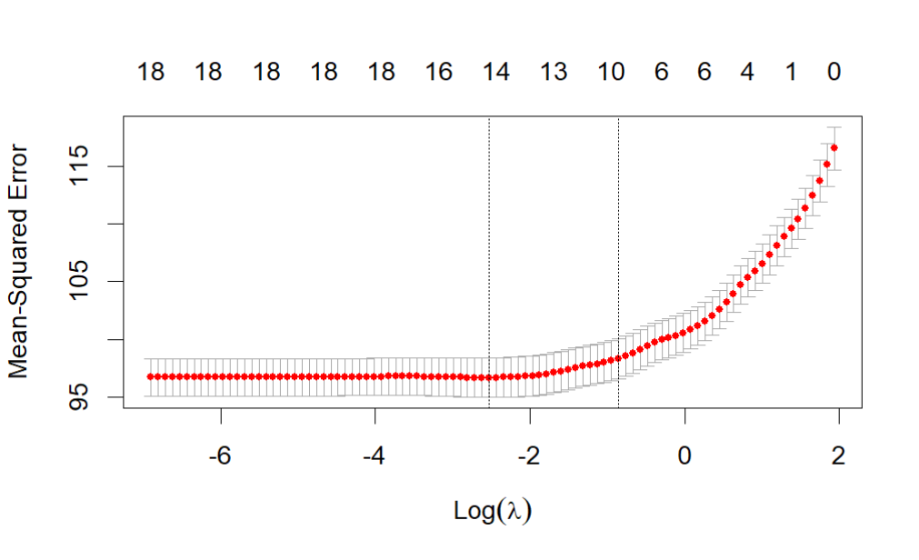

MSE Elastic net over lambda

### Question 3a ii

We range k from 1 to 15 and set up the control for model training using 10-fold cross-validation, repeated 10 times to provide a robust estimate of model performance.

The choose k = 4 because it has the lowest RMSE.

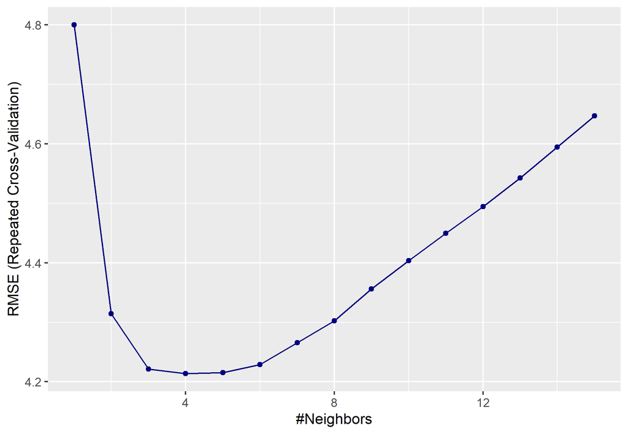

RMSE of KNN from k = 1 to 15

### Question 3a iii

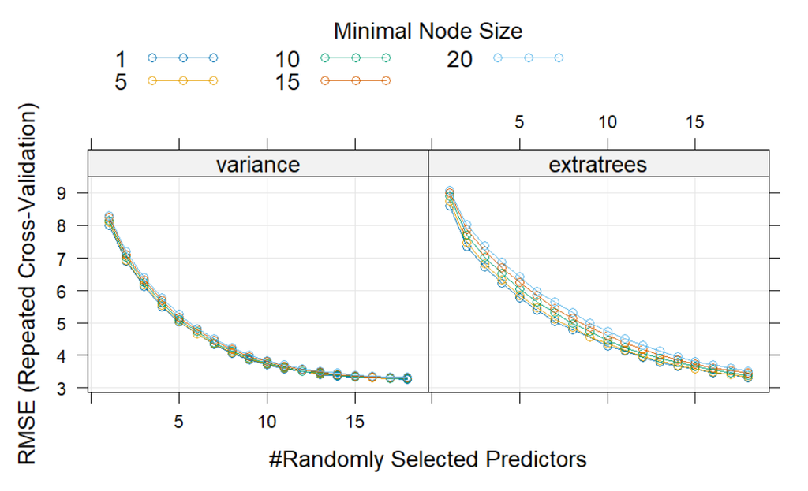

Random forests grid RMSE

### Question 3a iv

We now fit the model using the xgboost algorithm. We search for the best hyperparameters using a grid search set to 100 boosting rounds and 10-fold cross validation repeated 10 times. We then fit the model using the best hyperparameters and predict the test data.

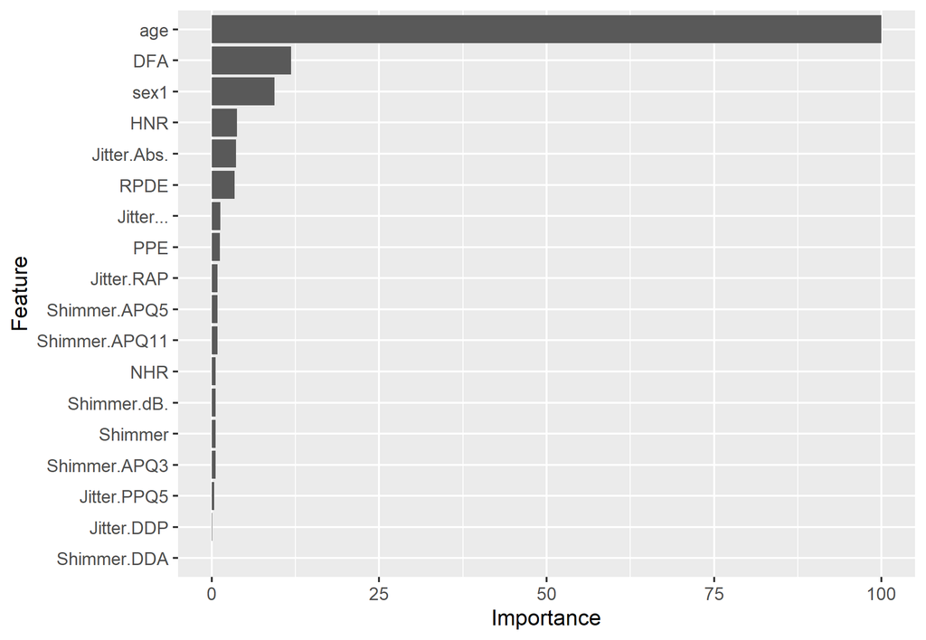

XGBoost Variable Importance

## Question 3b

The table below shows the test MSE of the 4 different models. Random forests produces the least MSE but an R squared of 51% and the parameters at best tune seem to overfit the model. So we shall choose XGBoost as the best model and use it to test the data performance with Q3testing.csv.

| Model | MSE |
| --- | --- |
| Elastic net (L1) | 95.59 |
| KNN | 14.90 |
| Random forest | 8.77 |
| XGBoost | 9.00 |

Below is the plot showing the RMSE of the XGBoost model. The selected model has a depth of 8. There is a low RMSE however its weakness is lack of interpretability. For lesser tree depths, where we have good interpretability, the RMSE has not yet converged.

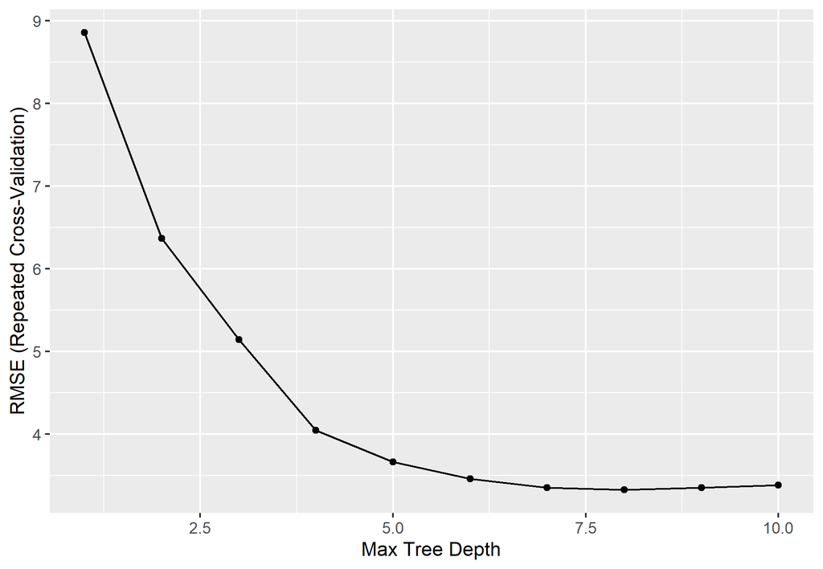

RMSE vs Maximum tree depth.

## Question 3c

The predictions for Q3testing are in MTSTIN007.csv. We train the selected XGBoost model on all the data for capturing more information on Q3testing.